# Basic data processing tutorial

ACouto

7 February 2018

# 1. Package installation

```r
install.packages("chron",repos = "http://cran.us.r-project.org")
install.packages("readxl", repos = "http://cran.us.r-project.org")
```

```r
install.packages("ggplot2",repos = "http://cran.us.r-project.org")
```

Be aware that some packages don’t work with some versions of R. For example “tidyr” only works with new versions of R. If you have more than one version of R (not R Studio) installed in the pc R Studio gives you the option of choosing which version you want to use: tools->global options-> R version. Additonally, when working on the university computers sometimes you might need to install the packages in other than the default library (H drive) due to permission restrictions. Use the command .libPaths(your path) to change the default library location. After installing the packages don’t forget to load them.

```r
library(chron)
library(readxl)
```

```r
library(ggplot2)
```

Set your working directory. If you are working with multiple files from different folders or you want to save the outputs in different folders, you can always create a vector with your folder path.

```r
setwd("C:\\Users\\r01ac17\\Desktop\\tutorial\\") # R will search for files in this folder
save.folder<-"C:\\Users\\r01ac17\\Desktop\\tutorial\\plots\\"
dir.create(save.folder) # create directory
```

# 2. Import data

We will work with elasmobranchii data from the Scottish West Coast Survey for commercial fish species dowloaded from http://www.iobis.org/mapper/. Use the command below to download the data.txt from the Github into your directory. For the excel data, download it directly from GitHub and place it in your working directory.

```r
download.file("https://raw.githubusercontent.com/Anofia/Basic-R-tutorial/master/data.txt", destfile = "data.txt")

data<-read.table("data.txt")
```

```
## Error in scan(file = file, what = what, sep = sep, quote = quote, dec = dec, : line 6 did not have 13 elements
```

```r
data<-read.table("data.txt", fill=TRUE) #fill=TRUE will solve the error by filling the gaps with NA
data<-read.table("data.txt", fill=TRUE, sep=",") #data is all in one column; wrong sep
data<-read.table("data.txt", fill=TRUE, sep="\t") #but colnames are not defined
data<-read.table("data.txt", fill=TRUE, sep="\t", header=TRUE)
head(data)
```

```
##          id                 tname datecollected latitude longitude depth
## 1 728038433 Scyliorhinus canicula    13/11/2003  59.2600   -4.2805    93
## 2 727973301      Leucoraja naevus    10/03/1987  55.4333   -9.2000   110
## 3 727974247 Scyliorhinus canicula    07/03/2004  58.6722   -7.2222   100
## 4 728044173      Leucoraja naevus    24/10/2001  59.2630   -4.2662    95
## 5 728044205      Leucoraja naevus    10/03/2001  56.4465   -7.4522   125
## 6 727979073     Squalus acanthias    26/11/2007  55.8277   -7.7367   120
##   temperature salinity nitrate oxygen phosphate silicate
## 1       9.020   35.216   9.449  6.100     0.691    4.053
## 2      10.174   35.368  10.156  5.910     0.684    4.026
## 3       9.818   35.289  10.420  5.916     0.688    3.963
## 4       9.020   35.216   9.449  6.100     0.691    4.053
## 5       9.645   35.299  10.524  5.785     0.734    4.677
## 6          NA       NA      NA     NA        NA       NA
```

To import data form excel you can use the folling code:

```r
data.excel<-read_excel("data.xlsx", sheet=1) # if you have multiple sheets you can choose which one to load
```

## 3. Data manipulation

Lets see if there are changes in the number of individuals per season and year. First we create separate columns with years and months.

```r
dates<-as.Date(data$datecollected)
head(dates) # what is wrong with this???
```

```
## [1] "0013-11-20" "0010-03-19" "0007-03-20" "0024-10-20" "0010-03-20"
## [6] "0026-11-20"
```

```r
head(data$datecollected) # dates are in format dd/mm/yyyy
```

```
## [1] 13/11/2003 10/03/1987 07/03/2004 24/10/2001 10/03/2001 26/11/2007
## 726 Levels: 01/03/1986 01/03/1991 01/03/1997 01/03/1998 ... 31/10/2001
```

```r
dates<-as.Date(data$datecollected, format="%d/%m/%Y")
head(dates) #perfect!
```

```
## [1] "2003-11-13" "1987-03-10" "2004-03-07" "2001-10-24" "2001-03-10"
## [6] "2007-11-26"
```

```r
data$month<-format(dates,"%m")
data$year<-format(dates,"%Y")
```

Because each row is an individual, we create a new column with a sequence of 1 to sum the number of indivuals per species, year and month

```r
data$n<-1
n.ind<-aggregate(n ~ tname + month+ year, data=data, FUN = sum)
colnames(n.ind)
```

```
## [1] "tname" "month" "year"  "n"
```

```r
colnames(n.ind)<-c("species","month","year","n") #change colnames
colnames(n.ind)
```

```
## [1] "species" "month"   "year"    "n"
```

```r
length(unique(n.ind$species)) #check how many species we have
```

```
## [1] 18
```

Using ggplot2 (see tutorial for ggplot2 as well) we will plot the number of individuals per month and per year for all the species combined and for each individual species.

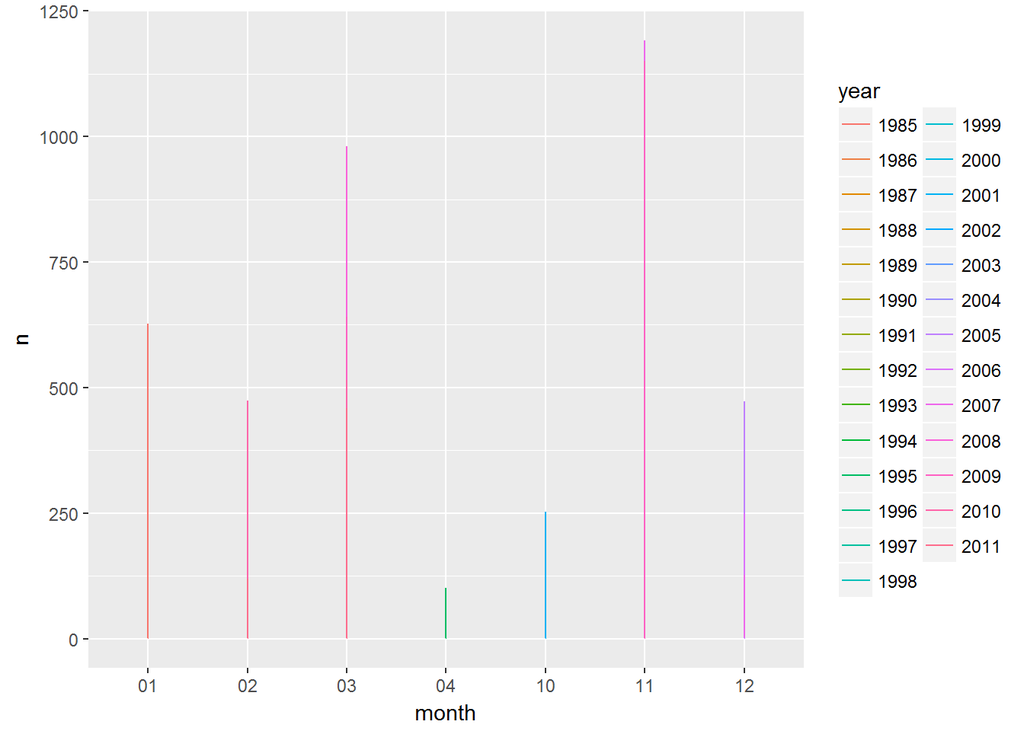

```r
ggplot(data=n.ind,aes(x=month, y=n, colour=year)) + geom_line() # this doesn't look good, why?
```

```r
class(n.ind$month)
```

```
## [1] "character"
```

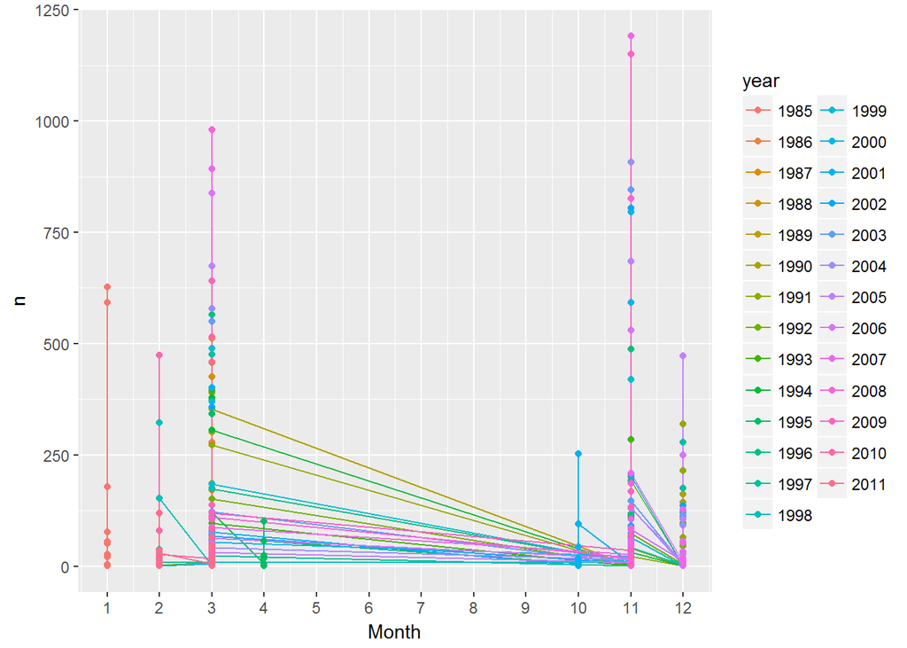

```r
ggplot(data=n.ind,aes(x=as.numeric(month), y=n, colour=year)) + geom_line() + geom_point() +scale_x_continuous(breaks=seq(1,12,1)) +xlab("Month")
```

[output not shown]

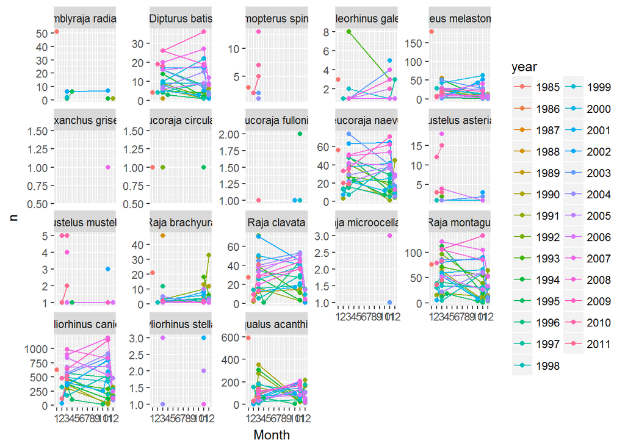

```r
ggplot(data=n.ind,aes(x=as.numeric(month), y=n, colour=year)) + geom_line() + geom_point() + facet_wrap(~species,scales=("free_y")) +scale_x_continuous(breaks=seq(1,12,1)) +xlab("Month")
```

For many species we only have a few observations. So lets look at only at one of the species that have higher values.

```r
unique(n.ind$species)
```

```
##  [1] Amblyraja radiata      Dipturus batis         Etmopterus spinax
##  [4] Galeorhinus galeus     Galeus melastomus      Leucoraja circularis
##  [7] Leucoraja naevus       Raja brachyura         Raja clavata
## [10] Raja montagui          Scyliorhinus canicula  Squalus acanthias
## [13] Mustelus asterias      Mustelus mustelus      Raja microocellata
## [16] Scyliorhinus stellaris Leucoraja fullonica    Hexanchus griseus
## 18 Levels: Amblyraja radiata Dipturus batis ... Squalus acanthias
```

```r
sp<-"Squalus acanthias" #variable with the species name that you want to select
sp.data<-data[which(data$tname==sp),] #select only rows for the selected species
head(sp.data)
```

```
##           id             tname datecollected latitude longitude depth
## 6  727979073 Squalus acanthias    26/11/2007  55.8277   -7.7367   120
## 24 728055338 Squalus acanthias    30/11/2003  58.0500   -6.1930   108
## 25 727989724 Squalus acanthias    17/11/1998  54.4833   -9.4833    98
## 26 727989767 Squalus acanthias    22/11/1998  53.7167   -5.6333    90
## 27 728056952 Squalus acanthias    10/03/2001  55.8238   -8.2635   156
## 31 727997875 Squalus acanthias    15/11/2003  58.6747   -7.2257    94
##    temperature salinity nitrate oxygen phosphate silicate month year n
## 6           NA       NA      NA     NA        NA       NA    11 2007 1
## 24          NA       NA      NA     NA        NA       NA    11 2003 1
## 25          NA       NA      NA     NA        NA       NA    11 1998 1
## 26      10.165   34.498   8.297  6.219     0.664    5.948    11 1998 1
## 27          NA       NA      NA     NA        NA       NA    03 2001 1
## 31       9.818   35.289  10.420  5.916     0.688    3.963    11 2003 1
```

```r
#try to change sp to "Scyliorhinus canicula" and re-run the sp.data
sp<-"Scyliorhinus canicula" #variable with the species name that you want to select
sp.data<-data[which(data$tname==sp),] #select only rows for the selected species
head(sp.data)
```

```
##           id                 tname datecollected latitude longitude depth
## 1  728038433 Scyliorhinus canicula    13/11/2003  59.2600   -4.2805    93
## 3  727974247 Scyliorhinus canicula    07/03/2004  58.6722   -7.2222   100
## 7  728047266 Scyliorhinus canicula    29/03/2005  59.2190   -4.1373   112
## 9  728052897 Scyliorhinus canicula    28/10/2001  58.0618   -9.0242   189
## 10 728053317 Scyliorhinus canicula    10/03/2001  55.8238   -8.2635   156
## 12 728053307 Scyliorhinus canicula    10/03/2001  55.8238   -8.2635   156
##    temperature salinity nitrate oxygen phosphate silicate month year n
## 1        9.020   35.216   9.449  6.100     0.691    4.053    11 2003 1
## 3        9.818   35.289  10.420  5.916     0.688    3.963    03 2004 1
## 7        9.020   35.216   9.449  6.100     0.691    4.053    03 2005 1
## 9        9.419   35.364  11.673  5.949     0.764    5.292    10 2001 1
## 10          NA       NA      NA     NA        NA       NA    03 2001 1
## 12          NA       NA      NA     NA        NA       NA    03 2001 1
```

As we have winter and spring data for Scyliorhinus canicula, lets check if there are any differences between seasons. First we create a new column with S for spring and W for winter using the function ifelse. Second we aggregate the total number of individuals per season and year. We can use a boxplot to see the differences between spring and winter and a t.test to see if this differences are significant.

```r
sp.data$season<-ifelse(as.numeric(sp.data$month)%in% c(3,4), "S", "W")
colnames(sp.data)
```

```
##  [1] "id"            "tname"         "datecollected" "latitude"
##  [5] "longitude"     "depth"         "temperature"   "salinity"
##  [9] "nitrate"       "oxygen"        "phosphate"     "silicate"
## [13] "month"         "year"          "n"             "season"
```

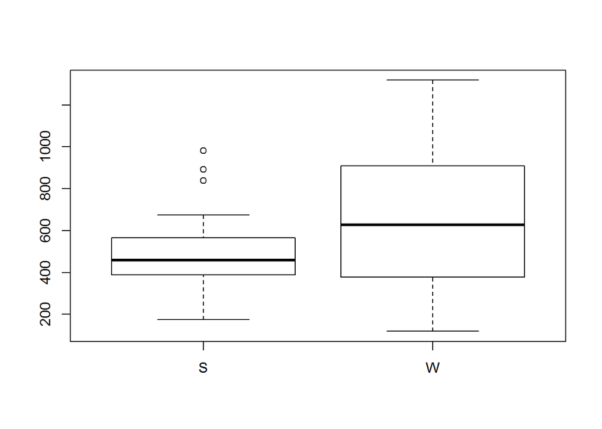

```r
n.sp<-aggregate(n ~ season + year, data=sp.data, FUN = sum)
boxplot(n~season, n.sp)
```

```r
t.test(n~season, n.sp)
```

```
##
##  Welch Two Sample t-test
##
## data:  n by season
## t = -1.9733, df = 32.577, p-value = 0.05699
## alternative hypothesis: true difference in means is not equal to 0
## 95 percent confidence interval:
##  -321.307003    4.985933
## sample estimates:
## mean in group S mean in group W
##        501.2308        659.3913
```

Now lets see if there are differences between the year for the overall average and for each season separately.

```r
mean.year<-aggregate(n ~ year , data=n.sp, FUN = mean) #mean
sd.year<-aggregate(n ~ year , data=n.sp, FUN = sd)#sd
year<-merge(mean.year, sd.year) #what is wrong?
year<-merge(mean.year, sd.year, by="year") # many functions will not give an error but they are not doing it properly - always check your data along the way

colnames(year)
```

```
## [1] "year" "n.x"  "n.y"
```

```r
colnames(year)<-c("year","mean","sd") #change colnames
colnames(year)
```

```
## [1] "year" "mean" "sd"
```

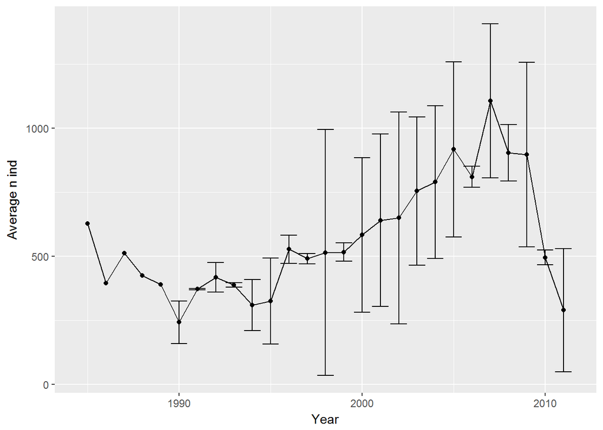

```r
ggplot(year, aes(x=as.numeric(year),y=mean))+geom_line()+geom_point()+xlab("Year")+ylab("Average n ind") + geom_errorbar(year, mapping=aes(x=as.numeric(year), ymin=mean-sd, ymax=mean+sd))
```

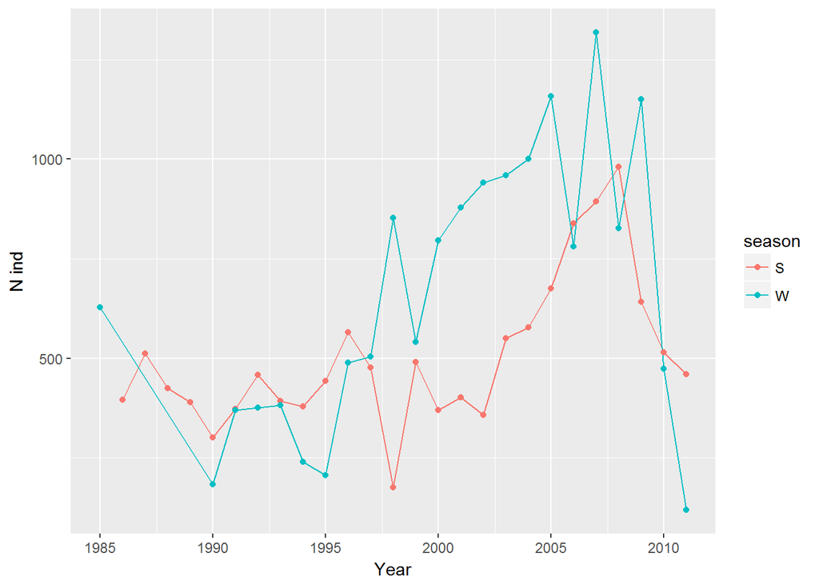

```r
#plot n ind per year for each season
ggplot(n.sp, aes(x=as.numeric(year),y=n, color=season))+geom_line()+geom_point()+xlab("Year")+ylab("N ind")
```

You can see that from 1997 there is an inversion in the general trend, with more sharks in winter than spring - lets see if there is any relation with environmental variables. To start we calculate the both the mean and max temperature per season and year. Notice that the data has a lot of NA. Arithmetic functions on NA yield NA. Aggregate automatically removes NA. But you can also remove the rows with NA in it yourself.

```r
colnames(sp.data)
```

```
##  [1] "id"            "tname"         "datecollected" "latitude"
##  [5] "longitude"     "depth"         "temperature"   "salinity"
##  [9] "nitrate"       "oxygen"        "phosphate"     "silicate"
## [13] "month"         "year"          "n"             "season"
```

```r
#mean sst
mean(sp.data$temperature) #NA
```

```
## [1] NA
```

```r
mean(sp.data$temperature, na.rm=TRUE)
```

```
## [1] 9.684336
```

```r
head(is.na(sp.data$temperature)) # this tells you which data are NA
```

```
## [1] FALSE FALSE FALSE FALSE  TRUE  TRUE
```

```r
na.sp.data<-sp.data[!is.na(sp.data$temperature), ] #! means the contrary: you want the observations that are not NA

mean.sst<-aggregate(temperature ~ season + year, data=sp.data, FUN = mean) #aggregate automatically deals with NAs
colnames(mean.sst)<-c("season","year","mean.temp")
max.sst<-aggregate(temperature ~ season + year, data=sp.data, FUN = max)
colnames(max.sst)<-c("season","year","max.temp")
#lets add temperature to n.sum
n.sp<-merge(n.sp,mean.sst,max.sst, by=c("season","year")) # merge only allows to merge 2 data frames
```

```
## Error in fix.by(by.x, x): 'by' must specify one or more columns as numbers, names or logical
```

```r
n.sp<-cbind(n.sp, mean.sst$mean.temp, max.sst$max.temp)
colnames(n.sp)<-c("season","year","n", "mean.temp","max.temp")
```

We can use a simple correlation test to see if there is any significant relation between temperature (max or mean) and number of individuals. Ploting the data with trend lines will allow you to see what is going on.

```r
cor.test(n.sp$n, n.sp$mean.temp) # there is no correlation between n ind and mean temperature
```

```
##
##  Pearson's product-moment correlation
##
## data:  n.sp$n and n.sp$mean.temp
## t = -0.80386, df = 47, p-value = 0.4255
## alternative hypothesis: true correlation is not equal to 0
## 95 percent confidence interval:
##  -0.3850450  0.1703164
## sample estimates:
##        cor
## -0.1164577
```

```r
cor.test(n.sp$n, n.sp$max.temp) # there is no correlation between n ind and max temperature
```

```
##
##  Pearson's product-moment correlation
##
## data:  n.sp$n and n.sp$max.temp
## t = -1.5016, df = 47, p-value = 0.1399
## alternative hypothesis: true correlation is not equal to 0
## 95 percent confidence interval:
##  -0.46705983  0.07153625
## sample estimates:
##        cor
## -0.2139644
```

```r
plot(n~mean.temp, n.sp, main="Mean sst")
# Add fit lines
abline(lm(n~mean.temp, n.sp), col="red") # regression line (y~x)
lines(lowess(mean.temp,n), col="blue") # lowess line (x,y) - error: R doesn't know where to get n or mean.temp
```

```
## Error in xy.coords(x, y, setLab = FALSE): object 'n' not found
```

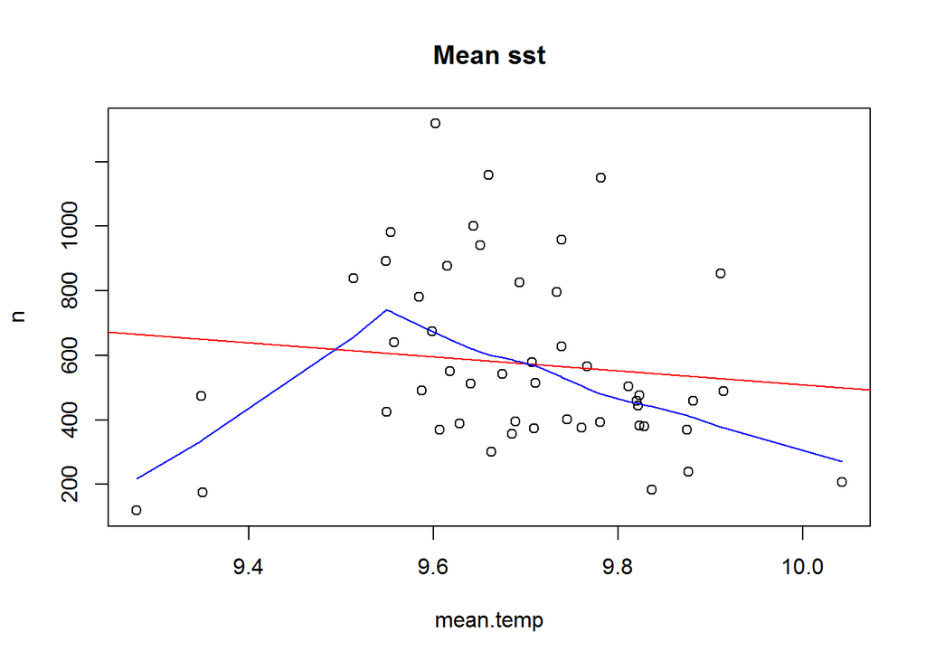

```r
lines(lowess(n.sp$mean.temp,n.sp$n), col="blue") # lowess line (x,y)
```

It seems that there are some extreme values in the data: this can bias/change the fit estimates and predictions. In some cases outliers don’t have to be removed, it depends if the data makes sense or if it as sampling error. other ways to deal with outliers are data transformation or use a different model. Two very good book on the subject are “Analysing ecological data” and “A beginner’s guide to R” for Alain Zuur. For this tutorial, we will treat extreme values as outliers to see the difference between the predictions. There are several methods to detect extreme values. we will use Cooks Distance method.

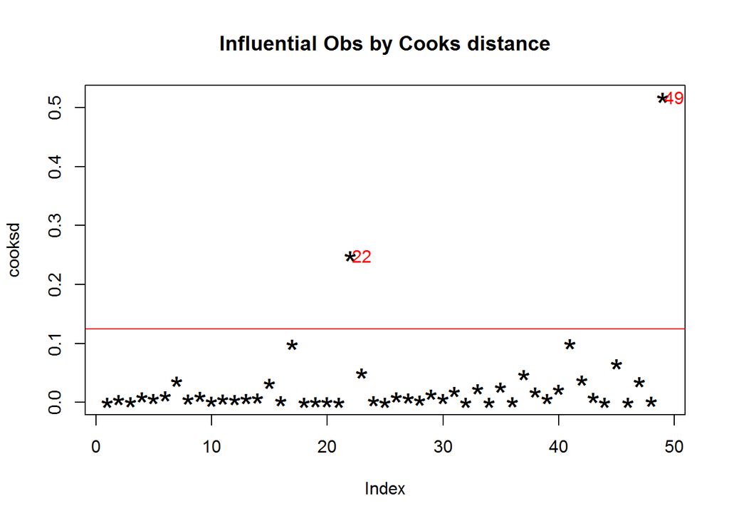

```r
mod<- lm(n~mean.temp, data=n.sp)
cooksd <- cooks.distance(mod) #Cooks Distance method
plot(cooksd, pch="*", cex=2, main="Influential Obs by Cooks distance")  # plot cook's distance
abline(h = 4*mean(cooksd, na.rm=T), col="red")  # add cutoff line; In general use, those observations that have a cook's distance greater than 4 times the mean may be classified as influential. This is not a hard boundary.
text(x=1:length(cooksd)+1, y=cooksd, labels=ifelse(cooksd>4*mean(cooksd, na.rm=T),names(cooksd),""), col="red")  # add labels
```

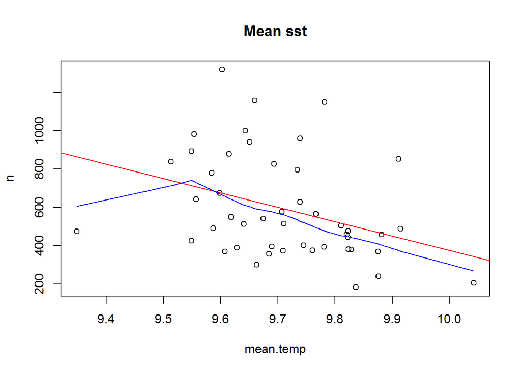

```r
outliers<-which(cooksd>4*mean(cooksd, na.rm=T))

#lets remove outliers and re check the correlations/plots
n.sp.out<-n.sp[-outliers,]
plot(n~mean.temp, n.sp.out, main="Mean sst")
# Add fit lines
abline(lm(n~mean.temp, n.sp.out), col="red") # regression line (y~x)
lines(lowess(n.sp.out$mean.temp,n.sp.out$n), col="blue") # lowess line (x,y)
```

```r
cor.test(n.sp.out$n, n.sp.out$mean.temp) # now the correlation between mean temperature and n indivuals is significative.
```

```
##
##  Pearson's product-moment correlation
##
## data:  n.sp.out$n and n.sp.out$mean.temp
## t = -2.5697, df = 45, p-value = 0.01356
## alternative hypothesis: true correlation is not equal to 0
## 95 percent confidence interval:
##  -0.58481553 -0.07863612
## sample estimates:
##        cor
## -0.3577249
```

One last thing before finish, lets plot the data with and without outliers side by side in and save it as jpeg.

```r
jpeg(filename=paste0(save.folder,"outliers.jpg")) # this opens the image
par(mfrow=c(1,2))
plot(n~mean.temp, n.sp, main="With outliers")
abline(lm(n~mean.temp, n.sp), col="red") # regression line (y~x)
lines(lowess(n.sp$mean.temp,n.sp$n), col="blue") # lowess line (x,y))

plot(n~mean.temp, n.sp.out, main="Without outliers")
abline(lm(n~mean.temp, n.sp.out), col="red") # regression line (y~x)
lines(lowess(n.sp.out$mean.temp,n.sp.out$n), col="blue") # lowess line (x,y))

dev.off () # this closes the image
```